# GraphBLAS in 10 seconds

- [GraphBLAS](https://graphblas.github.io/) is a **fast** sparse linear algebra library
- It is designed for **graph algorithms** in the language of **linear algebra**
  - **Powerful** enough for other use cases!
- Use from Python with [**`grblas`**](https://github.com/metagraph-dev/grblas) (our library) and `pygraphblas`

[figure not shown]

*Presenter: [Erik Welch](https://github.com/eriknw/) (Anaconda)*

# GraphBLAS in 30 seconds...

- This is an **adjacency matrix** with *edge weights*
- Each **row** shows the **out-edges** of a node
- Each **column** shows the **in-edges** of a node

```python
A  # click on my output!
```

**`A0` grblas.Matrix nvals nrows ncols dtype 12 7 7 INT64**

|  | 0 | 1 | 2 | 3 | 4 | 5 | 6 |
| --- | --- | --- | --- | --- | --- | --- | --- |
| 0 |  | 2 |  | 3 |  |  |  |
| 1 |  |  |  |  | 8 |  | 4 |
| 2 |  |  |  |  |  | 1 |  |
| 3 | 3 |  | 3 |  |  |  |  |
| 4 |  |  |  |  |  | 7 |  |
| 5 |  |  | 1 |  |  |  |  |
| 6 |  |  | 5 | 7 | 3 |  |  |

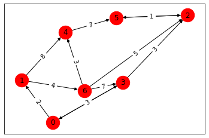

```python
draw(A)
```

## One step of **single-source-shortest-path (SSSP)**

```python
v  # This is our "frontier"; we start from node 1
```

**`v0` grblas.Vector nvals size dtype 1 7 INT64**

|  | 0 | 1 | 2 | 3 | 4 | 5 | 6 |
| --- | --- | --- | --- | --- | --- | --- | --- |
|  |  | 0 |  |  |  |  |  |

```python
semiring.min_plus(A.T @ v).new(name='baby_step')  # One step
```

**`babystep` grblas.Vector nvals size dtype 2 7 INT64**

|  | 0 | 1 | 2 | 3 | 4 | 5 | 6 |
| --- | --- | --- | --- | --- | --- | --- | --- |
|  |  |  |  |  | 8 |  | 4 |

- *Wait, what just happened?*
- Why did we need `.new()`?
- What's a **Semiring**?

### Without `.new()`, this is a **lazy expression**

```python
semiring.min_plus(A.T @ v)  # Click me too!
```

**`grblas.VectorExpression:`** A0.T.mxv(v0, op=semiring.min_plus[INT64]) size dtype 7 INT64**

> **`A0.T` grblas.TransposedMatrix nvals nrows ncols dtype 12 7 7 INT64**

> |  | 0 | 1 | 2 | 3 | 4 | 5 | 6 |
> | --- | --- | --- | --- | --- | --- | --- | --- |
> | 0 |  |  |  | 3 |  |  |  |
> | 1 | 2 |  |  |  |  |  |  |
> | 2 |  |  |  | 3 |  | 1 | 5 |
> | 3 | 3 |  |  |  |  |  | 7 |
> | 4 |  | 8 |  |  |  |  | 3 |
> | 5 |  |  | 1 |  | 7 |  |  |
> | 6 |  | 4 |  |  |  |  |  |

> **`v0` grblas.Vector nvals size dtype 1 7 INT64**

> |  | 0 | 1 | 2 | 3 | 4 | 5 | 6 |
> | --- | --- | --- | --- | --- | --- | --- | --- |
> |  |  | 0 |  |  |  |  |  |

*Do `expr.new()` or `other << expr` to calculate the expression.*

## Side note: most things in `grblas` are **lazy**

- `A.T` is **lazy**; it will set the "transpose descriptor"
- `A.T @ v` is **lazy**; we can still specify the **Semiring**
- `semiring.min_plus(A.T @ v)` is **lazy**; there is much we can still do!
- and more!

### This allows `grblas` to match **math notation** used by GraphBLAS

- *Trust us:* this may be **weird**, but **it's worth it**!
- Take a peek [here](https://arxiv.org/pdf/2104.01661.pdf#page=4) and [here](https://raw.githubusercontent.com/DrTimothyAldenDavis/GraphBLAS/stable/Doc/GraphBLAS_UserGuide.pdf#page=28)
- Advanced topics: **masks**, **accumulators**, **replace**, **non-blocking**

# BinaryOps, Monoids, and Semirings... oh my!

- NumPy **matrix multiply** `A @ b` supports **one** **Semiring**: `plus``-``times`
  - This is standard matrix multiply
  - `plus` is the **Monoid** (associative, commutative, has identity)
  - `times` is the **BinaryOp** (no constraints)
- GraphBLAS matrix multiply supports **arbitrary** **Semirings**!
  - For example, `min``-``plus` is used to calculate **shortest path**
  - `plus` **BinaryOp** computes path lengths
  - `min` **Monoid** determines the shortest path length
  - **Missing** elements are **ignored** (not assumed to be `0`)
- *Am I moving too fast?* **That's okay**. Keep going...

# GraphBLAS in 2 minutes

- GraphBLAS is actually a **C API specification** (pdf)
- [**SuiteSparse:GraphBLAS**](https://github.com/DrTimothyAldenDavis/GraphBLAS) by [Tim Davis](https://twitter.com/docsparse) is the main **implementation** (pdf)
- *Have I mentioned that SuiteSparse:GraphBLAS is **FAST**!*

## Also, graph computation is **hard**

- **Irregular** access patterns -> **poor locality** -> cache misses and cache invalidation
- Difficult to **scale** and **parallelize**
- Difficult to write optimized, readable, portable code

**Intuition about NumPy and dense linear algebra is of little help!**

# GraphBLAS **does not** specify memory layout

- There are many, many sparse matrix formats
  - See: https://docs.scipy.org/doc/scipy/reference/sparse.html
- GraphBLAS objects are **opaque**; the internals are hidden
- GraphBLAS operations can be **non-blocking** and **lazy**
  - Implementations may **delay** computation to allow for **optimizations**
- **End result:** users *think* and *program* in terms of **linear algebra**, not data structures
- But, SuiteSparse:GraphBLAS and `grblas` don't hide the format
  - We support **zero-copy** to and from **common formats** such as CSR and CSC
  - The user get and set the formats they want to use

# Single-source-shortest-path (SSSP) cont'd

- From a starting node, what is the shortest distance to get to any node?
- Recall our data:

```python
A
```

**`A0` grblas.Matrix nvals nrows ncols dtype 12 7 7 INT64**

|  | 0 | 1 | 2 | 3 | 4 | 5 | 6 |
| --- | --- | --- | --- | --- | --- | --- | --- |
| 0 |  | 2 |  | 3 |  |  |  |
| 1 |  |  |  |  | 8 |  | 4 |
| 2 |  |  |  |  |  | 1 |  |
| 3 | 3 |  | 3 |  |  |  |  |
| 4 |  |  |  |  |  | 7 |  |
| 5 |  |  | 1 |  |  |  |  |
| 6 |  |  | 5 | 7 | 3 |  |  |

```python
v
```

**`v0` grblas.Vector nvals size dtype 1 7 INT64**

|  | 0 | 1 | 2 | 3 | 4 | 5 | 6 |
| --- | --- | --- | --- | --- | --- | --- | --- |
|  |  | 0 |  |  |  |  |  |

## Step 1

- We **accumulate** the result of the matrix multiplication into `v` using `min`
- This keeps around the **previous best path** to that node
  - In this case, the cost to go from node 1 to itself is **0**

```python
v(binary.min) << semiring.min_plus(A.T @ v)
v
```

**`v0` grblas.Vector nvals size dtype 3 7 INT64**

|  | 0 | 1 | 2 | 3 | 4 | 5 | 6 |
| --- | --- | --- | --- | --- | --- | --- | --- |
|  |  | 0 |  |  | 8 |  | 4 |

# Step 2

- Expressions of the form `left << right` is **sugar** for `left.update(right)`
- It is used to **assign into** an existing data structure
- Things we can put on the left:
  - **Accumulators** such as `binary.min`
  - **Masks**, which indicate whether or not to save to a location
  - **Assign** indices (using square brackets)
  - **replace**, which we won't cover here

```python
v(binary.min) << semiring.min_plus(A.T @ v)
v
```

**`v0` grblas.Vector nvals size dtype 6 7 INT64**

|  | 0 | 1 | 2 | 3 | 4 | 5 | 6 |
| --- | --- | --- | --- | --- | --- | --- | --- |
|  |  | 0 | 9 | 11 | 7 | 15 | 4 |

# Step 3 and 4

- No change between step 3 and 4, so we're done!

```python
v(binary.min) << semiring.min_plus(A.T @ v)
v
```

**`v0` grblas.Vector nvals size dtype 7 7 INT64**

|  | 0 | 1 | 2 | 3 | 4 | 5 | 6 |
| --- | --- | --- | --- | --- | --- | --- | --- |
|  | 14 | 0 | 9 | 11 | 7 | 10 | 4 |

```python
v(binary.min) << semiring.min_plus(A.T @ v)
v
```

**`v0` grblas.Vector nvals size dtype 7 7 INT64**

|  | 0 | 1 | 2 | 3 | 4 | 5 | 6 |
| --- | --- | --- | --- | --- | --- | --- | --- |
|  | 14 | 0 | 9 | 11 | 7 | 10 | 4 |

# Another look

```python
v
```

**`v0` grblas.Vector nvals size dtype 7 7 INT64**

|  | 0 | 1 | 2 | 3 | 4 | 5 | 6 |
| --- | --- | --- | --- | --- | --- | --- | --- |
|  | 14 | 0 | 9 | 11 | 7 | 10 | 4 |

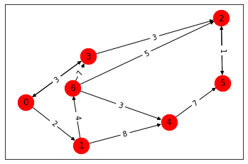

```python
draw(A)
```

# What does the C call look like?

- Use **Recorder** to show GraphBLAS calls

```python
with Recorder() as rec:
    v(binary.min) << semiring.min_plus(A.T @ v)
print(rec)
```

```
grblas.Recorder (not recording)
-------------------------------
  GrB_mxv(v_0, NULL, GrB_MIN_INT64, GrB_MIN_PLUS_SEMIRING_INT64, A_0, v_0, GrB_DESC_T0);
```

```python
with Recorder() as rec:
    w = A[0, :].new(mask=v.S, name='w')
print(rec)
```

```
grblas.Recorder (not recording)
-------------------------------
  GrB_Vector_new(&w, GrB_INT64, 7);
  GrB_Col_extract(w, v_0, NULL, A_0, GrB_ALL, 7, 0, GrB_DESC_ST0);
```

# "Interesting, but how do I get it?"

- `conda install -c conda-forge grblas`
- `pip install grblas`
- Works on **Linux**, **OS X**, and **Windows**

# "And what about `pygraphblas`?"

- We are **allies**! We are **working together** and **unifying** where we can.
- [`pygraphblas`](https://github.com/Graphegon/pygraphblas) came first and has [better documentation](https://graphegon.github.io/pygraphblas/pygraphblas/index.html) (we're working on this)
- The two libraries have different syntax and design philosophies
  - `grblas` is **lazy**. `pygraphblas` **is not**.
- For example: `A.T`
  - `grblas`: set the "transpose descriptor" in the C call
  - `pygraphblas`: immediately compute the transpose
    - This can be **expensive** and not what you want

**Can use both!**

# More resources

- https://github.com/metagraph-dev/grblas
- https://graphegon.github.io/pygraphblas/pygraphblas/index.html
- https://graphblas.github.io/GraphBLAS-Pointers/
- Slides by [Gábor Szárnyas](https://github.com/szarnyasg)
  - http://mit.bme.hu/~szarnyas/grb/graphblas-algorithms.pdf
  - https://archive.fosdem.org/2020/schedule/event/graphblas/attachments/slides/4053/export/events/attachments/graphblas/slides/4053/graphblas_fosdem_2020.pdf
- Slides by [Aydın Buluç](https://people.eecs.berkeley.edu/~aydin/)
  - https://people.eecs.berkeley.edu/~aydin/190219.1710_Buluc_GraphBLASGenomics_FINAL.pdf
  - https://people.eecs.berkeley.edu/~aydin/Buluc-CSE-Feb2019-16x9ver.pdf
  - https://people.eecs.berkeley.edu/~aydin/Buluc-ACS-Reverse.pdf